# Lecture 321

2020-08-31

## Simple Regression

## Recap

**Prev**: Comparing data

- 311 Lecture Comparing groups
- 312 Lecture Correlation
- 313 Lecture Data transformations
- 314 Practical session

**Now**: Simple Regression

- Regression
- Ordinary Least Squares
- Fit

## Regression analysis

**Regression analysis** is a supervised machine learning approach

Predict the value of one outcome variable as

\[outcome_i = (model) + error_i \]

- one predictor variable (**simple / univariate** regression)

\[Y_i = (b_0 + b_1 * X_{i1}) + \epsilon_i \]

- more predictor variables (**multiple / multivariate** regression)

\[Y_i = (b_0 + b_1 * X_{i1} + b_2 * X_{i2} + \dots + b_M * X_{iM}) + \epsilon_i \]

## Least squares

**Least squares** is the most commonly used approach to generate a regression model

The model fits a line

- to minimise the squared values of the **residuals** (errors)
- that is squared difference between
  - **observed values**
  - **model**

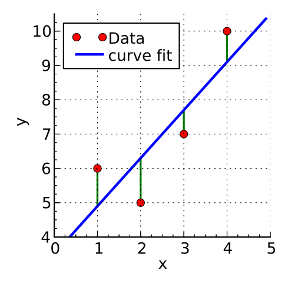

by Krishnavedala  
via Wikimedia Commons,  
CC-BY-SA-3.0

\[deviation = \sum(observed - model)^2\]

## Libraries and data

```r
library(tidyverse)
library(magrittr)
library(nycflights13)

flights_nov_20 <- nycflights13::flights %>%
  filter(!is.na(dep_delay), !is.na(arr_delay), month == 11, day ==20)
```

## Example

\[arr\_delay_i = (b_0 + b_1 * dep\_delay_{i1}) + \epsilon_i \]

```r
delay_model <- flights_nov_20 %$% # Note %$%
  lm(arr_delay ~ dep_delay)

delay_model %>%  summary()
```

```
##
## Call:
## lm(formula = arr_delay ~ dep_delay)
##
## Residuals:
##     Min      1Q  Median      3Q     Max
## -43.906  -9.022  -1.758   8.678  57.052
##
## Coefficients:
##             Estimate Std. Error t value Pr(>|t|)
## (Intercept) -4.96717    0.43748  -11.35   <2e-16 ***
## dep_delay    1.04229    0.01788   58.28   <2e-16 ***
## ---
## Signif. codes:  0 '***' 0.001 '**' 0.01 '*' 0.05 '.' 0.1 ' ' 1
##
## Residual standard error: 13.62 on 972 degrees of freedom
## Multiple R-squared:  0.7775, Adjusted R-squared:  0.7773
## F-statistic:  3397 on 1 and 972 DF,  p-value: < 2.2e-16
```

## Overall fit

The output indicates

- **p-value: < 2.2e-16**: \(p<.001\) the model is significant
  - derived by comparing the calulated **F-statistic** value to F distribution 3396.74 having specified degrees of freedom (1, 972)
  - Report as: F(1, 972) = 3396.74
- **Adjusted R-squared: 0.7773**: the departure delay can account for 77.73% of the arrival delay
- **Coefficients**
  - Intercept estimate -4.9672 is significant
  - `dep_delay` (slope) estimate 1.0423 is significant

## Parameters

\[arr\_delay_i = (Intercept + Coefficient_{dep\_delay} * dep\_delay_{i1}) + \epsilon_i \]

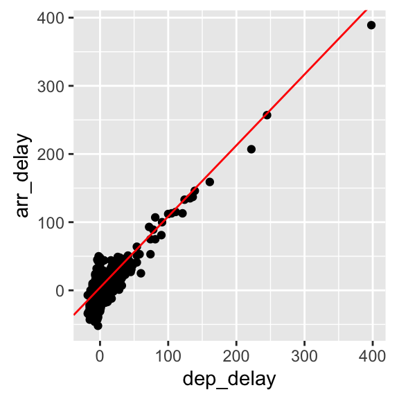

```r
flights_nov_20 %>%
  ggplot(aes(x = dep_delay, y = arr_delay)) +
  geom_point() + coord_fixed(ratio = 1) +
  geom_abline(intercept = 4.0943, slope = 1.04229, color="red")
```

## Summary

Simple Regression

- Regression
- Ordinary Least Squares
- Fit

**Next**: Assessing regression assumptions

- Normality
- Homoscedasticity
- Independence